# Survey 11 - What’s new?

Prepared by: UK

Last update: 2021-11-10

## DEMOGRAPHICS GLOBAL SAMPLE Survey 11

- Data presented here were collected between 2021-06-04 06:43:14 and 2021-09-21 07:06:05
- This data were collected from 706 people.
- **Self-reported** average age of participants: 44 years old.
- Participant ages ranged from 16 to 110 years old
- Sample is 68.1 % (*N* = 481) female

## Where are participants from?

Table 1 shows the breakdown of numbers of participants by continent and month.

Table 2 shows ISO codes of countries that included at least 30 responses.

**Legend**: *ARG* = Argentina, *CAN* = Canada, *CHE* = Switzerland, *COL* = Colombia, *FRA* = France, *IRL* = Ireland

[Source](https://www.iban.com/country-codes)

| continent | 2021-06 | 2021-07 | 2021-08 | 2021-09 |
| --- | --- | --- | --- | --- |
| Africa | 9 | 1 | NA | NA |
| Americas | 168 | 117 | 10 | NA |
| Asia | 17 | 6 | 3 | NA |
| Europe | 239 | 35 | 10 | 1 |
| Oceania | 14 | 4 | 9 | NA |
| NA | 26 | 27 | 9 | 1 |

| iso3_code | n |
| --- | --- |
|  | 63 |
| ARG | 35 |
| CAN | 159 |
| CHE | 148 |
| COL | 45 |
| FRA | 50 |
| IRL | 33 |

## Vaccination rates in Sample 11

*NB* - proportion include missing data (NA)

| Vaccinated? | N | Proportion |
| --- | --- | --- |
| No | 175 | 0.25 |
| Yes (partially) | 131 | 0.19 |
| Yes (fully) | 253 | 0.36 |
| Pref. not to answer | 7 | 0.01 |
| NA | 140 | 0.20 |

### For those unvaccinated: If COVID-19 vaccine was available to you today, how likely are you to get it?

Only people who responded “No” to the question above (i.e. N = 175) are considered in this question.

| Likelihood | N | Proportion |
| --- | --- | --- |
| Extremely likely | 47 | 0.27 |
| Somewhat likely | 16 | 0.09 |
| Somewhat unlikely | 12 | 0.07 |
| Extremely unlikely | 98 | 0.56 |
| Pref. not to answer | 2 | 0.01 |

# IMMUNIZATION PASSPORTS

The question of immunization passports has been popular already in Survey 9 and 10. We decided to inspect the answers again, this time for those who were *not vaccinated* and provided responses.

## To what extent would the introduction of ‘immunity passports’ influence your decision to get vaccinated?

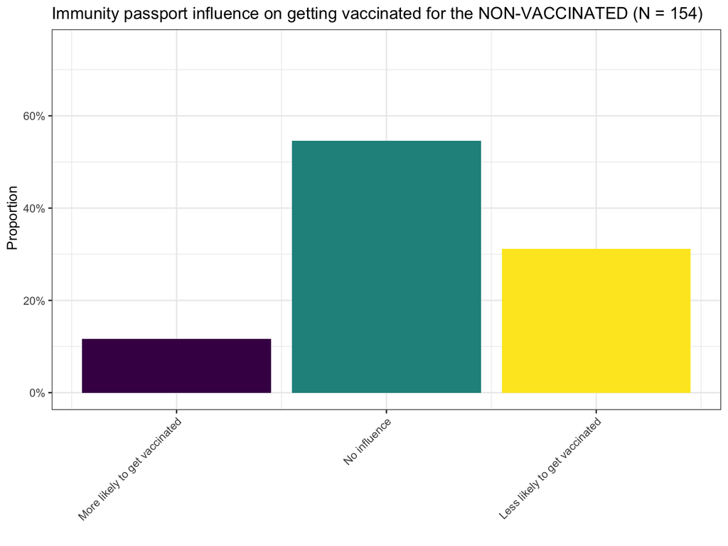

### Table corresponding to the plot

1 = It would make me more likely to get vaccinated 2 = No influence 3 = Less likely to get vaccinated

| Level of influence | N | Proportion |
| --- | --- | --- |
| 1 | 18 | 11.69 |
| 2 | 84 | 54.55 |
| 3 | 48 | 31.17 |

## NEW VARIABLES added to the Survey 11

### VACCINE BOOSTERS: If a booster dose of vaccine (an extra administration of a vaccine after an earlier dose) was required, how likely are you to get it?

Missing data (NA values) are accounted for when calculating the proportion.

| Likelihood | N | Proportion |
| --- | --- | --- |
| Extremely likely | 343 | 0.49 |
| Somewhat likely | 78 | 0.11 |
| Somewhat unlikely | 13 | 0.02 |
| Extremely unlikely | 98 | 0.14 |
| Pref. not to answer | 15 | 0.02 |
| NA | 159 | 0.23 |

### VACCINATION & CHILDREN

#### Have any of your children under 18 years of age received a COVID-19 vaccine?

| Response | N | Proportion |
| --- | --- | --- |
| No | 112 | 0.85 |
| Yes, partially | 10 | 0.08 |
| Yes, fully | 8 | 0.06 |
| Pref. not to answer | 2 | 0.02 |

#### If a vaccine for COVID-19 were available for your child/children, what is the likelihood that you would get them vaccinated?

| Likelihood | N | Proportion |
| --- | --- | --- |
| Extremely likely | 38 | 0.33 |
| Somewhat likely | 19 | 0.17 |
| Somewhat unlikely | 18 | 0.16 |
| Extremely unlikely | 36 | 0.32 |
| Pref. not to answer | 3 | 0.03 |

## MOTIVATION TO VACCINATE KIDS

The plot is broken down by parental attitudes about vaccinating their children if there was a vaccine available* (data collected prior approval of vaccines for individuals younger than age 12)

The plots are showing number of people responding to a great extent to each individual item. The x axis is fixed for the ease of comparison.

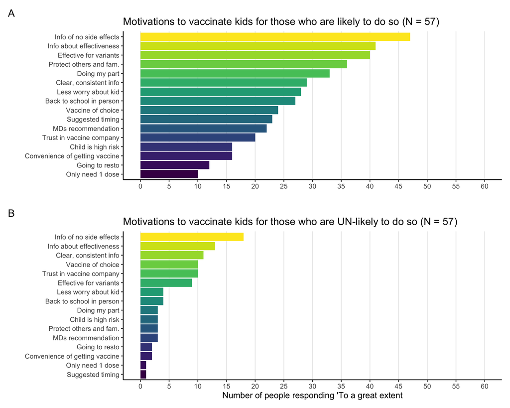